# BEMA analysis of sequencing depth

This script requires these steps to be current:

- Run `BEMA_DataInput.Rmd` to generate `BEMA100.RData`
- Run `BEMA100.Rmd` to generate diversity metrics. 4

```r
library(wesanderson)
library(scales)
library(nlme)
```

```r
# setwd('~/Dropbox/BEMA/bacteriaHTS/closed_ref_pickedOTUs/R/countData')
counts <- read.delim('../../Avg_assigned_seqs_files/harvestStats/summaryStatsAll.txt',
                     sep='\t', head=TRUE, skip=1)
map <- read.delim('../../mergedMap.txt', sep='\t', head=TRUE)
names(map)[1] <- gsub('X.', '', names(map)[1])
aves <- read.delim('aveSeqs.txt', sep='\t', head=TRUE)
hrj <- read.delim('../BEMAHRJ.txt', sep='\t', head=TRUE)
col22 <- as.character(read.delim('wescols.txt', head=FALSE)$V1)
load('../SourceTrackerResults2015.RData')
sT.full <- results$proportions
alphaDiv <- read.delim('../alphaDiversity.txt', head=TRUE, row.names=1)
```

```r
head(map)
str(map)
head(counts)
str(counts)
head(hrj)
str(hrj)
dim(map); dim(counts); dim(hrj)
```

```r
row.names(counts) <- counts$sampleName
row.names(map) <- map$SampleID
namesToKeep.tmp <- intersect(row.names(counts), row.names(map))
namesToKeep <- intersect(namesToKeep.tmp, row.names(hrj))
dat <- data.frame(counts[namesToKeep, ], map[namesToKeep, ], hrj[namesToKeep, ])
# head(dat)
```

After checking, most of these samples are from larger studies that dropped out of the OTU tables because of no reads, so they can just be taken out of further analysis.

This sets up a few contrasting colors. Humans are terrible at differentiating more than about 15 colors, and we need 23 at times. So here are a few sets of 23 unique colors that hopefully contrast well enough. This package (`wesanderson`) was written by Karthik Ram ([https://github.com/karthik/wesanderson.git](https://github.com/karthik/wesanderson)).

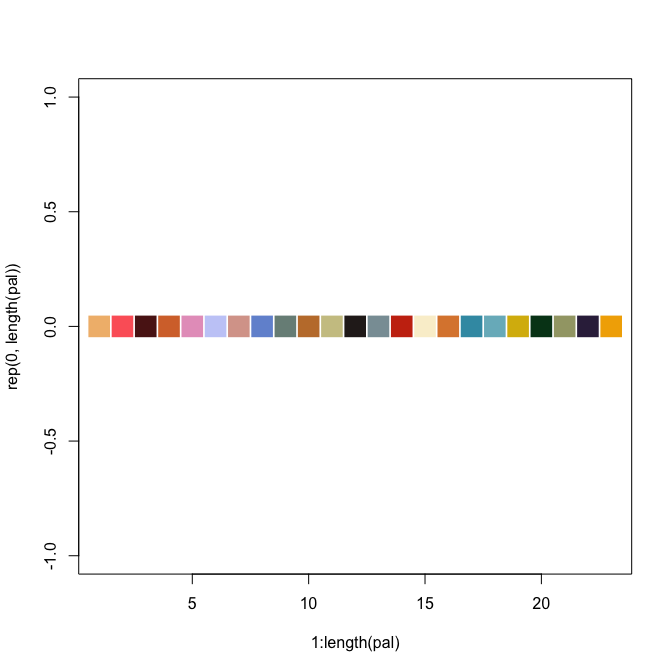

```r
# pal <- wes.palette(name='Zissou', type='continuous')(22)

# pal <- c(
#   wes.palette(4, 'GrandBudapest'),
#   wes.palette(4, 'GrandBudapest2'),
#   wes.palette(4, 'Moonrise2'),
#   wes.palette(4, 'Royal1'),
#   wes.palette(2, 'Zissou'),
#   wes.palette(3, 'Cavalcanti'),
#   wes.palette(5, 'Rushmore')[4],
#   wes.palette(5, 'Darjeeling')[3])


pal <- c(
  wes_palette('GrandBudapest', 4),
  wes_palette('GrandBudapest2', 4),
  wes_palette('Moonrise2', 4),
  wes_palette('Royal1', 4),
  wes_palette('Zissou', 2),
  wes_palette('Cavalcanti', 3),
  wes_palette('Rushmore', 5)[4],
  wes_palette('Darjeeling', 5)[3])


plot(1:length(pal), rep(0, length(pal)), pch=15, cex=3, col=pal)
```

```r
# pal <- col22

studyLevels <- levels(dat$Description)
dat$col <- NULL
for(i in 1:length(studyLevels)) {
  dat$col[dat$Description == studyLevels[i]] <- pal[i]
  }
```

```
grep '^[GATC].*' seqs.fna | awk '{sum+=length($0)}END{print sum/NR}'
```

```r
dat$aveSeqLength <- 0
# aves
for(i in 1:nrow(aves)) {
  dat$aveSeqLength[dat$Description == aves$StudyName[i]] <- aves$avgSeqLength[i]
}
```

Plots of:

- Number of sequences assigned with barcodes (passed quality filtering) ~ the percent per sample in final OTU table. This is assessment of quality sequences that mapped to GreenGenes database.
- Similar but ~ number of observations in OTU table instead of percent. Interesting to note the slight departure from 1:1 for a couple of studies.

This exhibits that these metrics are very much biased by each study. Studies tend to cluster, and some are well mixed, but overall, clustered by study.

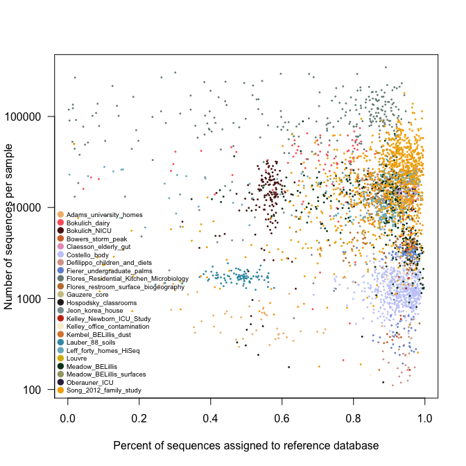

```r
# par(mar=c(
plot(dat$splitTotal ~ dat$percentAssigned, pch=16, cex=.4, col=dat$col,
     log='y', yaxt='n',
     xlab='Percent of sequences assigned to reference database',
     ylab='Number of sequences per sample')
axis(2, at=c(0, 100, 1000, 10000, 100000),
     labels=c('0', '100', '1000', '10000', '100000'), las=1)
legend('bottomleft', legend=unique(dat$Description), col=unique(dat$col),
       pch=16, cex=.6, bty='n', pt.cex=1.3)
```

```r
plot(dat$splitTotal ~ dat$otuTableTotal, log='xy', pch=16, cex=.2, col=dat$col)
legend('bottomright', legend=unique(dat$Description), col=unique(dat$col),
       pch=16, cex=.6, bty='n', pt.cex=1.3)
```

Shannon-Weiner diversity ~ percent of quality sequences assigned in OTU table. Asking if closed ref biases alpha diversity. Big difference. Think about what this means. Very study dependent, but certainly worth reporting. This plot gets remade with better treatment later.

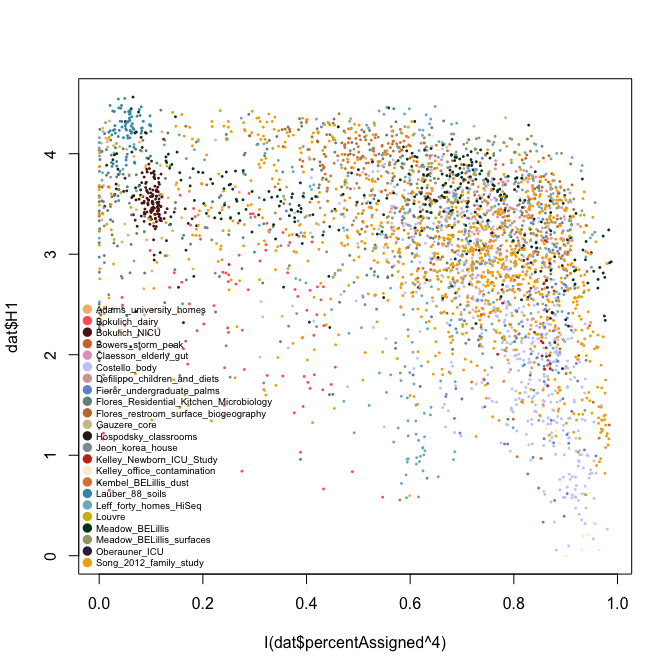

```r
plot(dat$H1 ~ I(dat$percentAssigned^4), pch=16, cex=.4, col=dat$col)
legend('bottomleft', legend=unique(dat$Description), col=unique(dat$col),
       pch=16, cex=.6, bty='n', pt.cex=1.3)
```

```r
summary(lm(dat$H1 ~ I(dat$percentAssigned^4)))
```

```
Call:
lm(formula = dat$H1 ~ I(dat$percentAssigned^4))

Residuals:
    Min      1Q  Median      3Q     Max
-3.1141 -0.4080  0.1291  0.5873  1.5248

Coefficients:
                         Estimate Std. Error t value Pr(>|t|)
(Intercept)               3.78908    0.03073  123.29   <2e-16 ***
I(dat$percentAssigned^4) -1.21867    0.04640  -26.27   <2e-16 ***
---
Signif. codes:  0 '***' 0.001 '**' 0.01 '*' 0.05 '.' 0.1 ' ' 1

Residual standard error: 0.7824 on 3857 degrees of freedom
Multiple R-squared:  0.1517,    Adjusted R-squared:  0.1515
F-statistic: 689.9 on 1 and 3857 DF,  p-value: < 2.2e-16
```

Bring in phylogenetic diversity and Shannon diversity created by QIIME.

```r
all(row.names(dat) %in% row.names(alphaDiv))
```

```
[1] TRUE
```

```r
dat$shDiv <- alphaDiv[row.names(dat), 'shannon']
dat$pd <- alphaDiv[row.names(dat), 'PD_whole_tree']
```

```r
se <- function(x) {sd(x)/sqrt(length(x))}
nstudies <- nlevels(dat$Description)
dat$percentAssigned4 <- dat$percentAssigned^4
divBars <- data.frame(#matrix(0, nrow=nstudies, ncol=8),
    meanX=aggregate(dat$percentAssigned4, by=list(dat$Description), FUN='mean')$x,
    meanY=aggregate(dat$H1, by=list(dat$Description), FUN='mean')$x,
    seX=aggregate(dat$percentAssigned4, by=list(dat$Description), FUN='se')$x,
    seY=aggregate(dat$H1, by=list(dat$Description), FUN='se')$x,
    sdX=aggregate(dat$percentAssigned4, by=list(dat$Description), FUN='sd')$x,
    sdY=aggregate(dat$H1, by=list(dat$Description), FUN='sd')$x)
row.names(divBars) <- levels(dat$Description)
divBars$seXplus <- divBars$meanX + divBars$sdX
divBars$seXminus <- divBars$meanX - divBars$sdX
divBars$seYplus <- divBars$meanY + divBars$sdY
divBars$seYminus <- divBars$meanY - divBars$sdY
divBars$sdXplus <- divBars$meanX + divBars$sdX
divBars$sdXminus <- divBars$meanX - divBars$sdX
divBars$sdYplus <- divBars$meanY + divBars$sdY
divBars$sdYminus <- divBars$meanY - divBars$sdY
divBars$col <- unique(dat$col)
divCoef <- summary(lm(dat$H1 ~ dat$percentAssigned4))$coefficients

divBars$meanPD <- aggregate(dat$pd, by=list(dat$Description), FUN='mean')$x
divBars$sePD <- aggregate(dat$pd, by=list(dat$Description), FUN='se')$x
divBars$sePDplus <- divBars$meanPD + divBars$sePD
divBars$sePDminus <- divBars$meanPD - divBars$sePD
divBars$sdPD <- aggregate(dat$pd, by=list(dat$Description), FUN='sd')$x
divBars$sdPDplus <- divBars$meanPD + divBars$sdPD
divBars$sdPDminus <- divBars$meanPD - divBars$sdPD
```

```r
se <- function(x) {sd(x)/sqrt(length(x))}
nstudies <- nlevels(dat$Description)
# dat$percentAssigned4 <- dat$percentAssigned^4
divBars1 <- data.frame(
    meanX=aggregate(dat$percentAssigned, by=list(dat$Description), FUN='mean')$x,
    seX=aggregate(dat$percentAssigned, by=list(dat$Description), FUN='se')$x,
    sdX=aggregate(dat$percentAssigned, by=list(dat$Description), FUN='sd')$x)
row.names(divBars1) <- levels(dat$Description)
divBars1$seXplus <- divBars1$meanX + divBars1$sdX
divBars1$seXminus <- divBars1$meanX - divBars1$sdX
divBars1$sdXplus <- divBars1$meanX + divBars1$sdX
divBars1$sdXminus <- divBars1$meanX - divBars1$sdX
divBars1$col <- unique(dat$col)
```

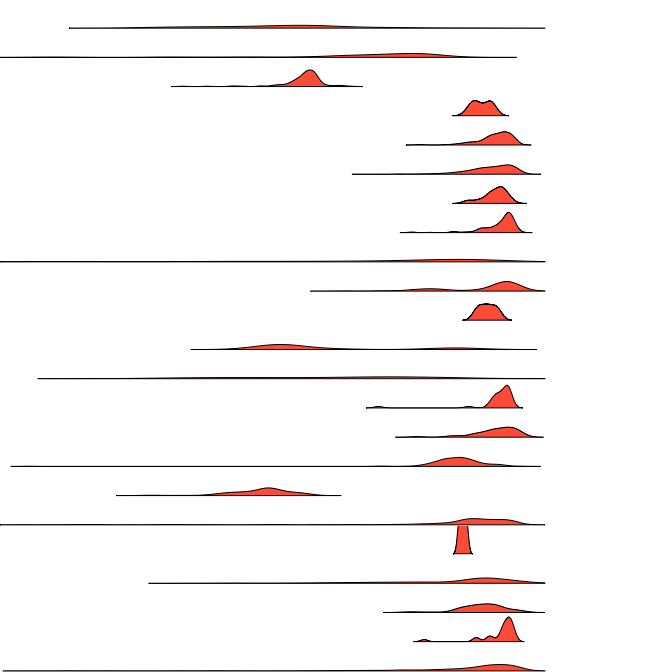

```r
par(mfrow=c(nstudies, 1), mar=c(0,0,0,10))
for(i in 1:nstudies){
  subDat <- dat$percentAssigned[dat$Description == levels(dat$Description)[i]]
  plot(0,0, type='n', ann=FALSE, axes=FALSE,
       xlim=c(0, max(dat$percentAssigned)), ylim=c(0, 30))
  polygon(density(dat$percentAssigned[dat$Description == levels(dat$Description)[i]]), col='tomato')
       }
```

See if they correlate: Shannon = yes; PD = quite different.

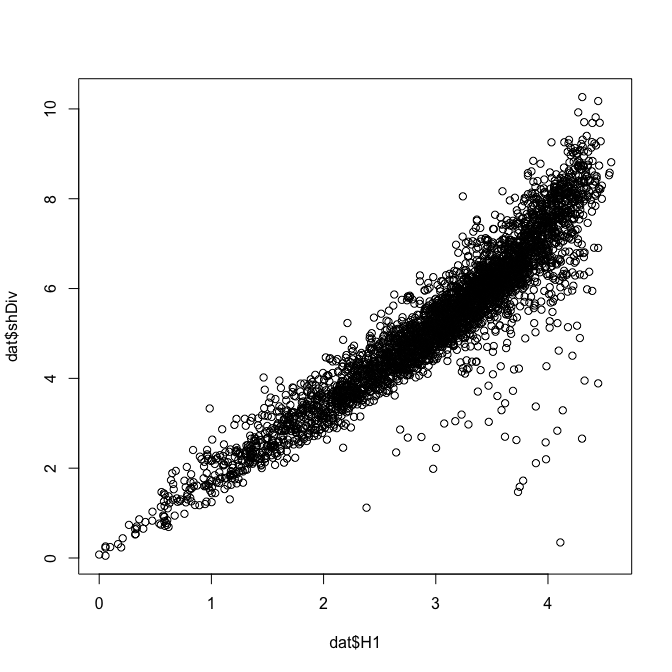

```r
plot(dat$H1, dat$shDiv)
```

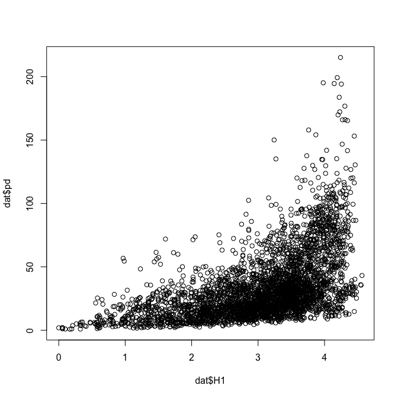

```r
plot(dat$H1, dat$pd)
```

```r
plot(dat$H1 ~ dat$percentAssigned4, type='n', las=1,
     ylab='Taxonomic Diversity', )
arrows(divBars$meanX, divBars$seYplus, divBars$meanX, divBars$seYminus,
       code=3, angle=90, length=.1, col='gray50')
arrows(divBars$seXplus, divBars$meanY, divBars$seXminus, divBars$meanY,
       code=3, angle=90, length=.1, col='gray')
points(divBars$meanX, divBars$meanY, pch=21, bg=divBars$col, cex=2, col='gray30')
legend('bottomleft', legend=unique(dat$Description), col=unique(dat$col),
       pch=16, cex=.6, bty='n', pt.cex=1.3)
```

```r
kit <- which(dat$Description == 'Flores_Residential_Kitchen_Microbiology')
summary(lm(dat$H1[kit] ~ dat$percentAssigned[kit]))
plot(dat$H1[kit] ~ dat$percentAssigned[kit], pch=16, cex=.4, col=dat$col[kit])
legend('bottomleft', legend=unique(dat$Description), col=unique(dat$col),
       pch=16, cex=.6, bty='n', pt.cex=1.3)
```

```r
leff <- which(dat$Description == 'Leff_forty_homes_HiSeq')
summary(lm(dat$H1[leff] ~ dat$percentAssigned[leff]))
plot(dat$H1[leff] ~ dat$percentAssigned[leff], pch=16, cex=.4, col=dat$col[leff])
legend('bottomleft', legend=unique(dat$Description), col=unique(dat$col),
       pch=16, cex=.6, bty='n', pt.cex=1.3)
```

Diversity ~ sequence depth per sample.

```r
par(mfrow=c(1,1), mar=c(5,4,4,1))
plot(dat$H1 ~ log(dat$splitTotal), pch=16, cex=.4, col=dat$col, xlim=c(4, 16))
legend('bottomright', legend=unique(dat$Description), col=unique(dat$col),
       pch=16, cex=.6, bty='n', pt.cex=1.3)
```

```r
plot(dat$H1 ~ dat$aveSeqLength, pch=16, cex=.4, col=dat$col)
legend('bottomleft', legend=unique(dat$Description), col=unique(dat$col),
       pch=16, cex=.6, bty='n', pt.cex=1.3)
summary(lm(dat$H1 ~ dat$aveSeqLength))
```

Percent of sequences mapping to GreenGenes ~ average sequening length per study. This is likely confounded by environment and study. Pull some out later to test.

```r
plot(dat$percentAssigned ~ dat$aveSeqLength, pch=16, cex=.4, col=dat$col,
     xlim=c(0, 530))
legend('bottomleft', legend=unique(dat$Description), col=unique(dat$col),
       pch=16, cex=.6, bty='n', pt.cex=1.3)
summary(lm(dat$percentAssigned ~ dat$aveSeqLength))
```

```r
plot(dat$percentAssigned ~ dat$aveSeqLength, pch=16, cex=.4, col=dat$col)
legend('bottomleft', legend=unique(dat$Description), col=unique(dat$col),
       pch=16, cex=.6, bty='n', pt.cex=1.3)
```

Test for interaction - think about what this means. Interesting and very strong.

```r
summary(lm(dat$H1 ~ dat$percentAssigned*dat$aveSeqLength))
```

```
Call:
lm(formula = dat$H1 ~ dat$percentAssigned * dat$aveSeqLength)

Residuals:
    Min      1Q  Median      3Q     Max
-3.4343 -0.4225  0.1142  0.5852  2.4899

Coefficients:
                                       Estimate Std. Error t value
(Intercept)                           2.6537721  0.1472380  18.024
dat$percentAssigned                   1.0212790  0.1800332   5.673
dat$aveSeqLength                      0.0097091  0.0007859  12.354
dat$percentAssigned:dat$aveSeqLength -0.0148376  0.0009805 -15.133
                                     Pr(>|t|)
(Intercept)                           < 2e-16 ***
dat$percentAssigned                  1.51e-08 ***
dat$aveSeqLength                      < 2e-16 ***
dat$percentAssigned:dat$aveSeqLength  < 2e-16 ***
---
Signif. codes:  0 '***' 0.001 '**' 0.01 '*' 0.05 '.' 0.1 ' ' 1

Residual standard error: 0.7823 on 3855 degrees of freedom
Multiple R-squared:  0.1523,    Adjusted R-squared:  0.1517
F-statistic: 230.9 on 3 and 3855 DF,  p-value: < 2.2e-16
```

```r
# pdf('~/Desktop/divPercent.pdf', width=9, height=7)
layout(matrix(c(1, 2), 1, 2), widths=3, 1)
par(mar=c(4, 4, 1, 0))
plot(dat$H1 ~ dat$percentAssigned4, las=1, pch=16, cex=.6,
     col=alpha(dat$col, alpha=0.7), #col=rgb(0,0,0,.2),
     ylab='Shannon-Wiener Taxonomic Diversity',
     xlab=expression((Percent~of~sequences~assigned~to~GreenGenes)^{4}))
curve(divCoef[1] + x*divCoef[2], add=TRUE, col='darkorange', lwd=2)
arrows(divBars$meanX, divBars$sdYplus, divBars$meanX, divBars$sdYminus,
       code=3, angle=90, length=.1, col='gray20')
arrows(divBars$sdXplus, divBars$meanY, divBars$sdXminus, divBars$meanY,
       code=3, angle=90, length=.1, col='gray20')
points(divBars$meanX, divBars$meanY, pch=21, bg=divBars$col, cex=2, col='gray20')
par(mar=c(4, 0, 1, 0))
plot(1,1, ann=FALSE, axes=FALSE, bty='n', type='n')
legend('bottomleft', legend=unique(dat$Description), pt.bg=unique(dat$col),
       col='gray20', pch=21, cex=.6, bty='n', pt.cex=1.4, y.intersp=1.2)
# dev.off()
```

```r
divOrdered <- divBars[rev(order(divBars$meanX)), ]
divOrdered1 <- divBars1[rev(order(divBars1$meanX)), ]
```

```r
plotdf <- divOrdered
y <- 1:nrow(plotdf)
x.lim <- c(0, 1) #range(plotdf[, c('seXminus', 'seXplus')])
par(las=1, mar=c(4, 15, 1, 1))
plot(plotdf$meanX, y, type='n', xlim=x.lim,
     ann=FALSE, xaxt='n', yaxt='n', xaxs='i')
abline(h=y, col='gray90', lty=3)
par(xpd=TRUE)
arrows(plotdf$seXminus, y,
       plotdf$seXplus, y,
       col='gray40', code=3, length=.03, angle=90)
par(xpd=FALSE)
points(plotdf$meanX, y, cex=2,
       pch=21, bg=plotdf$col, col='gray30')
mtext(row.names(plotdf), at=y, side=2, line=0.5, cex=.9)
axis(1)
mtext('Proportion of sequences assigned\nin GreenGenes Database',
      side=1, at=.5, line=3)
```

```r
par(mfrow=c(1,1), mar=c(5,4,4,1), fg='gray40', xpd=TRUE)
plot(dat$pd ~ dat$percentAssigned4, las=1, pch=16, cex=.6,
     xaxs='i', bty='o', xaxt='n',
     col=alpha(dat$col, alpha=0.7), #col=rgb(0,0,0,.2),
     ylab='', xlab='', log='y')
arrows(divBars$meanX, divBars$sdPDplus, divBars$meanX, divBars$sdPDminus,
       code=3, angle=90, length=.03, col='gray20')
arrows(divBars$sdXplus, divBars$meanPD, divBars$sdXminus, divBars$meanPD,
       code=3, angle=90, length=.03, col='gray20')
points(divBars$meanX, divBars$meanPD, pch=21, bg=divBars$col, cex=2, col='gray20')
```

```r
summary(lm(log(dat$pd) ~ dat$percentAssigned4))
```

```
Call:
lm(formula = log(dat$pd) ~ dat$percentAssigned4)

Residuals:
     Min       1Q   Median       3Q      Max
-3.16070 -0.44998 -0.00037  0.48305  1.98957

Coefficients:
                     Estimate Std. Error t value Pr(>|t|)
(Intercept)           3.58896    0.02930  122.50   <2e-16 ***
dat$percentAssigned4 -0.58749    0.04423  -13.28   <2e-16 ***
---
Signif. codes:  0 '***' 0.001 '**' 0.01 '*' 0.05 '.' 0.1 ' ' 1

Residual standard error: 0.7458 on 3857 degrees of freedom
Multiple R-squared:  0.04374,   Adjusted R-squared:  0.0435
F-statistic: 176.4 on 1 and 3857 DF,  p-value: < 2.2e-16
```

```r
summary(lm(dat$pd ~ dat$percentAssigned4))
```

```
Call:
lm(formula = dat$pd ~ dat$percentAssigned4)

Residuals:
    Min      1Q  Median      3Q     Max
-39.737 -16.557  -7.426   7.852 177.920

Coefficients:
                     Estimate Std. Error t value Pr(>|t|)
(Intercept)           42.7766     0.9897   43.22   <2e-16 ***
dat$percentAssigned4 -15.8341     1.4941  -10.60   <2e-16 ***
---
Signif. codes:  0 '***' 0.001 '**' 0.01 '*' 0.05 '.' 0.1 ' ' 1

Residual standard error: 25.19 on 3857 degrees of freedom
Multiple R-squared:  0.02829,   Adjusted R-squared:  0.02804
F-statistic: 112.3 on 1 and 3857 DF,  p-value: < 2.2e-16
```

```r
summary(lm(dat$pd ~ I(dat$percentAssigned4^2)))
```

```
Call:
lm(formula = dat$pd ~ I(dat$percentAssigned4^2))

Residuals:
    Min      1Q  Median      3Q     Max
-40.884 -15.892  -6.895   8.127 174.559

Coefficients:
                          Estimate Std. Error t value Pr(>|t|)
(Intercept)                43.4597     0.7513   57.84   <2e-16 ***
I(dat$percentAssigned4^2) -23.3620     1.4520  -16.09   <2e-16 ***
---
Signif. codes:  0 '***' 0.001 '**' 0.01 '*' 0.05 '.' 0.1 ' ' 1

Residual standard error: 24.74 on 3857 degrees of freedom
Multiple R-squared:  0.06289,   Adjusted R-squared:  0.06265
F-statistic: 258.9 on 1 and 3857 DF,  p-value: < 2.2e-16
```

```r
summary(lm(divBars$meanPD ~ divBars$meanX))
summary(lm(divBars$meanY ~ divBars$meanX))
```

```r
lme.div <- lme(H1 ~ percentAssigned4, random = ~ 1 | Description, data=dat)
summary(lme.div)
```

```
Linear mixed-effects model fit by REML
 Data: dat
       AIC      BIC    logLik
  8290.984 8316.015 -4141.492

Random effects:
 Formula: ~1 | Description
        (Intercept)  Residual
StdDev:   0.4888806 0.6997917

Fixed effects: H1 ~ percentAssigned4
                     Value  Std.Error   DF   t-value p-value
(Intercept)       3.873086 0.11047729 3835  35.05776       0
percentAssigned4 -1.194011 0.05789144 3835 -20.62500       0
 Correlation:
                 (Intr)
percentAssigned4 -0.287

Standardized Within-Group Residuals:
       Min         Q1        Med         Q3        Max
-4.4992085 -0.5053513  0.1200248  0.6598599  2.2164563

Number of Observations: 3859
Number of Groups: 23
```

```r
lme.div.coef <- lme.div$coefficients$fixed


lme.div2 <- lme(H1 ~ percentAssigned4 + I(percentAssigned4^2), random = ~ 1 | Description, data=dat)
summary(lme.div2)
```

```
Linear mixed-effects model fit by REML
 Data: dat
       AIC      BIC    logLik
  7996.212 8027.499 -3993.106

Random effects:
 Formula: ~1 | Description
        (Intercept)  Residual
StdDev:   0.4857768 0.6732092

Fixed effects: H1 ~ percentAssigned4 + I(percentAssigned4^2)
                          Value Std.Error   DF   t-value p-value
(Intercept)            3.320979 0.1137425 3834  29.19735       0
percentAssigned4       2.019797 0.1908044 3834  10.58569       0
I(percentAssigned4^2) -3.089555 0.1754123 3834 -17.61311       0
 Correlation:
                      (Intr) prcnA4
percentAssigned4      -0.343
I(percentAssigned4^2)  0.276 -0.956

Standardized Within-Group Residuals:
       Min         Q1        Med         Q3        Max
-4.7396561 -0.5042140  0.1072872  0.6569441  2.6823185

Number of Observations: 3859
Number of Groups: 23
```

```r
lme.div2.coef <- lme.div2$coefficients$fixed


lme.pd <- lme(pd ~ percentAssigned4, random = ~ 1 | Description, data=dat)
summary(lme.pd)
```

```
Linear mixed-effects model fit by REML
 Data: dat
       AIC      BIC    logLik
  33917.89 33942.92 -16954.94

Random effects:
 Formula: ~1 | Description
        (Intercept) Residual
StdDev:    20.66003 19.35339

Fixed effects: pd ~ percentAssigned4
                     Value Std.Error   DF   t-value p-value
(Intercept)       37.32666  4.476669 3835  8.338042       0
percentAssigned4 -10.14152  1.610276 3835 -6.298000       0
 Correlation:
                 (Intr)
percentAssigned4 -0.197

Standardized Within-Group Residuals:
        Min          Q1         Med          Q3         Max
-3.51696912 -0.51301294 -0.06805337  0.31994546  8.13476534

Number of Observations: 3859
Number of Groups: 23
```

```r
lme.pd.coef <- lme.pd$coefficients$fixed


lme.pd2 <- lme(pd ~ percentAssigned4 + I(percentAssigned4^2), random = ~ 1 | Description, data=dat)
summary(lme.pd2)
```

```
Linear mixed-effects model fit by REML
 Data: dat
      AIC      BIC    logLik
  33612.1 33643.39 -16801.05

Random effects:
 Formula: ~1 | Description
        (Intercept) Residual
StdDev:    18.48115 18.61829

Fixed effects: pd ~ percentAssigned4 + I(percentAssigned4^2)
                          Value Std.Error   DF    t-value p-value
(Intercept)            21.67232  4.120738 3834   5.259331       0
percentAssigned4       79.72441  5.292706 3834  15.063072       0
I(percentAssigned4^2) -86.25995  4.859157 3834 -17.752040       0
 Correlation:
                      (Intr) prcnA4
percentAssigned4      -0.264
I(percentAssigned4^2)  0.213 -0.956

Standardized Within-Group Residuals:
        Min          Q1         Med          Q3         Max
-3.71590566 -0.53978094 -0.03651019  0.33336827  8.17288155

Number of Observations: 3859
Number of Groups: 23
```

```r
lme.pd2.coef <- lme.pd2$coefficients$fixed
```

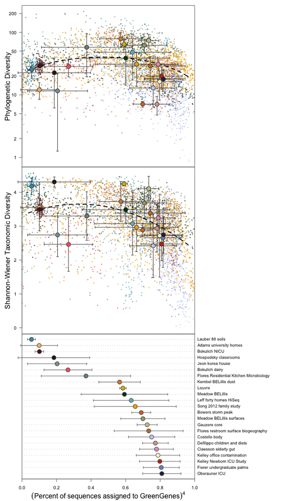

```r
plotdf <- divOrdered
# pdf('~/Desktop/techVarFigure.pdf', width=9, height=9)
layout(matrix(c(1, 2, 3, 4, 5, 6), 3, 2), widths=c(2,1))



par(mar=c(0, 4, 1, 0), fg='gray40', xpd=TRUE)
plot(dat$pd ~ dat$percentAssigned4, las=1, pch=16, cex=.6,
     xaxs='i', bty='o', xaxt='n',
     col=alpha(dat$col, alpha=0.7), #col=rgb(0,0,0,.2),
     ylab='', xlab='', log='y')
mtext('Phylogenetic Diversity', side=2, line=2, las=0, col='black')
# curve(lme.pd.coef[1] + x*lme.pd.coef[2], add=TRUE, col='black', lwd=2, lty=2)
curve(lme.pd2.coef[1] + x*lme.pd2.coef[2] + (x^2)*lme.pd2.coef[3], add=TRUE, col='black', lwd=2, lty=2)
arrows(divBars$meanX, divBars$sdPDplus, divBars$meanX, divBars$sdPDminus,
       code=3, angle=90, length=.03, col='gray20')
arrows(divBars$sdXplus, divBars$meanPD, divBars$sdXminus, divBars$meanPD,
       code=3, angle=90, length=.03, col='gray20')
points(divBars$meanX, divBars$meanPD, pch=21, bg=divBars$col, cex=2, col='gray20')



par(mar=c(0, 4, 0, 0), fg='gray40', xpd=TRUE)
plot(dat$H1 ~ dat$percentAssigned4, las=1, pch=16, cex=.6,
     xaxs='i', bty='o', xaxt='n',
     col=alpha(dat$col, alpha=0.7), #col=rgb(0,0,0,.2),
     ylab='', xlab='')
mtext('Shannon-Wiener Taxonomic Diversity', side=2, line=2, las=0, col='black')
# curve(divCoef[1] + x*divCoef[2], add=TRUE, col='black', lwd=2, lty=2)
# curve(lme.div.coef[1] + x*lme.div.coef[2], add=TRUE, col='black', lwd=2, lty=2)
curve(lme.div2.coef[1] + x*lme.div2.coef[2] + (x^2)*lme.div2.coef[3], add=TRUE, col='black', lwd=2, lty=2)
arrows(divBars$meanX, divBars$sdYplus, divBars$meanX, divBars$sdYminus,
       code=3, angle=90, length=.03, col='gray20')
arrows(divBars$sdXplus, divBars$meanY, divBars$sdXminus, divBars$meanY,
       code=3, angle=90, length=.03, col='gray20')
points(divBars$meanX, divBars$meanY, pch=21, bg=divBars$col, cex=2, col='gray20')
# par(mar=c(4, 0, 1, 0))
# plot(1,1, ann=FALSE, axes=FALSE, bty='n', type='n')
# legend('bottomleft', legend=unique(dat$Description), pt.bg=unique(dat$col),
#        col='gray20', pch=21, cex=.6, bty='n', pt.cex=1.4, y.intersp=1.2)
# dev.off()


# divOrdered <- divBars[rev(order(divBars$meanX)), ] # happens above
y <- 1:nrow(plotdf)
x.lim <- c(0, 1) #range(plotdf[, c('seXminus', 'seXplus')])
par(las=1, mar=c(4, 4, 0, 0), xpd=FALSE)
plot(plotdf$meanX, y, type='n', xlim=x.lim,
     ann=FALSE, xaxt='n', yaxt='n', xaxs='i',
     bty='o')
abline(h=y, col='gray80', lty=3)
par(xpd=TRUE)
arrows(plotdf$seXminus, y,
       plotdf$seXplus, y,
       col='gray40', code=3, length=.03, angle=90)
par(xpd=FALSE)
points(plotdf$meanX, y, cex=2,
       pch=21, bg=plotdf$col, col='gray30')
#mtext(row.names(plotdf), at=y, side=2, line=0.5, cex=.9)
axis(1)
mtext(expression((Percent~of~sequences~assigned~to~GreenGenes)^{4}),
      side=1, at=.5, line=3, col='black')

par(mar=c(0,0,1,0))
plot(1,1,ann=FALSE,xaxt='n',yaxt='n',type='n',bty='n')
par(mar=c(0,0,0,0))
plot(1,1,ann=FALSE,xaxt='n',yaxt='n',type='n',bty='n')
par(mar=c(4,0,0,0))
plot(1,1,ann=FALSE,xaxt='n',yaxt='n',type='n',bty='n',
     ylim=c(1,nrow(divOrdered)), xlim=c(0,1), xaxs='i')
text(x=0, y=c(1:nrow(divOrdered)),
     gsub('_', ' ', row.names(plotdf)),
     pos=4, col='black', cex=.9)
```

```r
studyNamesOrig <- row.names(plotdf)

studyNamesDisplay <- c('Austria ICU',
                       'Colorado undergraduate palms',
                       'California NICU (SD)',
                       'California office',
                       'Ireland elderly gut',
                       'Europe/Africa children gut',
                       'Colorado body sites',
                       'Colorado restroom surfaces',
                       'France building air',
                       'Oregon classroom surfaces',
                       'Colorado mountaintop air',
                       'Colorado family',
                       'North Carolina homes',
                       'Oregon classroom air',
                       'France museum air',
                       'Oregon university dust',
                       'Colorado kitchen surfaces',
                       'California dairy',
                       'South Korea homes',
                       'Connecticut classroom air',
                       'California NICU (Sac)',
                       'California residence air (Berk)',
                       'N + S America soils')
studyNames <- data.frame(studyNamesOrig, studyNamesDisplay)
```

```r
plotdf <- divOrdered1
pdf('perAssigned.pdf', height=4, width=6, useDingbats=FALSE)
y <- 1:nrow(plotdf)
x.lim <- c(.4, 1)#range(plotdf[, c('seXminus', 'seXplus')])
par(las=1, mar=c(3, 1, 1, 9), xpd=FALSE)
plot(plotdf$meanX, y, type='n', xlim=x.lim,
     ann=FALSE, xaxt='n', yaxt='n', xaxs='i',
     bty='n')
abline(h=y, col='gray80', lty=3)
par(xpd=TRUE)
arrows(plotdf$seXminus, y,
       plotdf$seXplus, y,
       col='gray40', code=3, length=.03, angle=90)
text(x=1.02, y=c(1:nrow(divOrdered)),
     gsub('_', ' ', studyNamesDisplay),
     pos=4, col='black', cex=.7)
par(xpd=FALSE)
points(plotdf$meanX, y, cex=2,
       pch=21, bg=plotdf$col, col='gray30')
axis(1, at=seq(.4, 1, .1), tck=.01, labels = FALSE, line=.5)
axis(1, at=seq(.4, 1, .2), tck=.02, labels=FALSE, line=.5)
axis(1, at=seq(.4, 1, .2), tick=FALSE, labels=seq(40, 100, 20), line=-.5, cex=.5)
mtext('Percent of sequences assigned to GreenGenes',
      side=1, at=.7, line=1.5, col='black')

dev.off()
```

```r
refNames <- row.names(divOrdered)
refNamesDisplay <- gsub('_', ' ', studyNamesDisplay)
refCol <- divOrdered$col

pdf('perAssigned_density.pdf', height=5, width=7, useDingbats=FALSE)

layout(matrix(c(1:(nstudies+2)), nstudies+2, 1), heights=c(.1, rep(1, nstudies), 3))
par(mar=c(0,1,0,19))
plot(0,0, type='n', ann=FALSE, axes=FALSE)
for(i in 1:nstudies){
  subDat <- density(dat$percentAssigned[dat$Description == refNames[i]])
  plot(0,0, type='n', ann=FALSE, axes=FALSE,
       xlim=c(0, max(dat$percentAssigned)),
       ylim=c(0, max(subDat$y)),
       xaxs='i')
  rect(0, 0, 1, 100, col='gray90', border='transparent')
  abline(v=seq(0, 1, .1), col=rgb(1,1,1), lwd=1)
  polygon(subDat, col=refCol[i])
  mtext(paste(refNamesDisplay[i], ' (', subDat$n, ')', sep=''),
        side=4, las=1, cex=.8, line=0.5)
  }
plot(0,0, type='n', ann=FALSE, axes=FALSE,
     xlim=c(0, max(dat$percentAssigned)),
     ylim=c(0, max(subDat$y)), xaxs='i')
par(xpd=TRUE)
axis(1, at=seq(0, 1, .1), tck=.05, labels = FALSE, line=-3)
axis(1, at=seq(0, 1, .2), tck=.1, labels=FALSE, line=-3)
axis(1, at=seq(0, 1, .2), tick=FALSE, labels=seq(00, 100, 20), line=-4, cex=.5)
mtext('Percent of sequences assigned to GreenGenes',
      side=1, at=.5, line=-1.5, col='black')

dev.off()
```

```r
# test <- density(dat$percentAssigned)
# names(test)
# test$n
```

```r
studyNamesDF <- data.frame(refNames, refNamesDisplay, refCol)
```

### Import source tracker

This is a pretty clear indication that using source tracker is heavily dependent on gene region. Ie, this goes to the broader point that any source tracker analysis should rely only on source samples within your own dataset. This is true for our analysis since we used sources that are all v1-v2, so these sinks are the most commonly classified.

```r
colnames(sT.full)
```

```
 [1] "kit_control"  "outdoor_air"  "source_ear"   "source_feces"
 [5] "source_mouth" "source_nose"  "source_skin"  "source_soil"
 [9] "source_urine" "Unknown"
```

```r
#sT.full[, 'Unknown']
all(row.names(sT.full) %in% row.names(map))  # so all in original map
```

```
[1] TRUE
```

```r
all(row.names(sT.full) %in% row.names(dat))  # but not in filtered dat
```

```
[1] FALSE
```

```r
sT <- data.frame(sT.full[which(row.names(sT.full) %in% row.names(dat)), ])
# head(dat)
sT$Target_Region <- as.character(dat[row.names(sT), 'Target_Region'])
sT$Description <- as.character(dat[row.names(sT), 'Description'])
sT$Known <- 1-sT$Unknown
# head(sT)
```

Make ordered set for barplots.

```r
se <- function(x) {sd(x)/sqrt(length(x))}

sTbars <- data.frame(matrix(0, length(unique(sT$Description)), 4))
row.names(sTbars) <- sort(unique(sT$Description))
names(sTbars) <- c('mean', 'se', 'sePlus', 'seMinus')
sTbars$mean <- aggregate(sT$Known, by=list(sT$Description), FUN=mean)$x
sTbars$se <- aggregate(sT$Known, by=list(sT$Description), FUN=se)$x
sTbars$sePlus <- sTbars$mean + sTbars$se
sTbars$seMinus <- sTbars$mean - sTbars$se

sTbars$seqTech <- ''

for (i in 1:nrow(sTbars)) {
  this <- row.names(sTbars)[i]
  sTbars$seqTech[i] <- names(table(sT$Target_Region[sT$Description == this]))
}

# cols5 <- rev(wes_palette('Darjeeling', 5))
# cols5 <- rev(wes.palette(5, 'Darjeeling2'))  # not here for some reason?
cols5 <- rev(wes_palette('Darjeeling2', 5))
sTbars$col <- ''
seqTech5 <- unique(sTbars$seqTech)[c(1, 4, 3, 2, 5)]

for(i in 1:length(unique(sTbars$seqTech))) {
  this <- seqTech5[i]
  sTbars$col[sTbars$seqTech == this] <- cols5[i]
  }

sTbars.sort <- sTbars[order(sTbars$mean), ]
```

```r
keepSources <- c('outdoor_air', 'source_ear', 'source_feces',
                 'source_mouth', 'source_nose', 'source_skin',
                 'source_urine', 'source_soil', 'kit_control', 'Unknown')
keepSourceNames <- c('Outdoor air', 'Ear', 'Feces', 'Mouth', 'Nose',
                     'Skin', 'Urine', 'Soil', 'Kit', 'Unknown')
sTsources <- aggregate(sT[, keepSources], by=list(sT$Description), FUN='mean')
row.names(sTsources) <- studyNames$studyNamesDisplay[match(sTsources$Group.1, studyNames$studyNamesOrig)]
sTsources <- sTsources[rev(order(sTsources$Unknown)), -1]

# cols.11 <- c('#A50026', '#D73027', '#F46D43', '#FDAE61', '#FEE090',
#             '#E0F3F8', '#ABD9E9', '#74ADD1', '#4575B4', '#313695', '#969A97')
cols.10 <- c('#A50026', '#D73027', '#F46D43', '#FDAE61', '#FEE090',
            '#ABD9E9', '#74ADD1', '#4575B4', '#313695', '#969A97')




par(mar=c(1, 12, 1, 1))
# barplot(t(sTsources), horiz=TRUE, las=1, col=cols.10, space = 0)
```

```r
dF <- sTbars.sort
newNames <- studyNames$studyNamesDisplay[match(row.names(dF), studyNames$studyNamesOrig)]
pdf('sTbars2015.pdf', width=8, height=5)
par(mar=c(5, 14, 1, 1), las=1)
mids <- barplot(dF$mean, horiz=TRUE, xaxt='n',
        col=dF$col, border='transparent', xlim=c(0,1))
abline(v=seq(0, 1, .1), col='white')
arrows(dF$seMinus, mids, dF$sePlus, mids,
       angle=90, code=3, length=.03)
mtext(newNames, side=2, at=mids, line=.3)
axis(1, at=seq(0, 1, .1), labels=FALSE, tck=-.01)
axis(1, at=seq(0, 1, .2), labels=c(0, 20, 40, 60, 80, 100))
legend('bottomright', legend=seqTech5, pch=15, col=cols5,
       pt.cex=2.5, bty='n')
mtext('Percent of OTUs assigned using SourceTracker', 1, line=2.3)
dev.off()
```

```r
dF <- sTbars.sort
newNames <- studyNames$studyNamesDisplay[match(row.names(dF), studyNames$studyNamesOrig)]
pdf('sTbarsWithSources.pdf', width=13, height=5)
layout(matrix(c(1,2),1,2), widths=c(1.3,1))
par(mar=c(5, 14, 1, 1), las=1)
mids <- barplot(dF$mean, horiz=TRUE, xaxt='n',
        col=dF$col, border='transparent', xlim=c(0,1))
abline(v=seq(0, 1, .1), col=rgb(1,1,1,.4))
arrows(dF$seMinus, mids, dF$sePlus, mids,
       angle=90, code=3, length=.03)
mtext(newNames, side=2, at=mids, line=.3)
axis(1, at=seq(0, 1, .1), labels=FALSE, tck=-.01)
axis(1, at=seq(0, 1, .2), labels=c(0, 20, 40, 60, 80, 100))
legend('bottomright', legend=seqTech5, pch=15, col=cols5,
       pt.cex=2.5, bty='n')
mtext('Percent of OTUs assigned using SourceTracker', 1, line=2.3)
mtext('(a)', side=3, adj=0, cex=1.5, font=2, line=-.5)

par(mar=c(5, 1, 1, 8), las=1)
barplot(t(sTsources), horiz=TRUE, las=1, col=cols.10, border='transparent',
        names.arg=rep('', nrow(sTsources)), axes=FALSE)
abline(v=seq(0, 1, .1), col=rgb(1,1,1,.4))
axis(1, at=seq(0, 1, .1), labels=FALSE, tck=-.01)
axis(1, at=seq(0, 1, .2), labels=c(0, 20, 40, 60, 80, 100))
par(xpd=TRUE)
legend(1, 10.8, legend=keepSourceNames, col=cols.10, pch=15, bty='n', pt.cex=2.5)
mtext('Percent of each source type assigned', 1, line=2.3)
mtext('(b)', side=3, adj=0, cex=1.5, font=2, line=-.5)


dev.off()
```

```r
dF <- sTbars.sort
newNames <- studyNames$studyNamesDisplay[match(row.names(dF), studyNames$studyNamesOrig)]
pdf('sTbarsWithSources2.pdf', width=13, height=5)
layout(matrix(c(1,2),1,2), widths=c(1,1.3))

par(mar=c(5, 7, 1, 1), las=1)
barplot(t(sTsources), horiz=TRUE, las=1, col=cols.10, border='transparent',
        names.arg=rep('', nrow(sTsources)), axes=FALSE)
abline(v=seq(0, 1, .1), col=rgb(1,1,1,.4))
axis(1, at=seq(0, 1, .1), labels=FALSE, tck=-.01)
axis(1, at=seq(0, 1, .2), labels=c(0, 20, 40, 60, 80, 100))
par(xpd=TRUE)
legend(-.35, 10.8, legend=keepSourceNames, col=cols.10, pch=15, bty='n', pt.cex=2.5)
mtext('Percent of each source type assigned', 1, line=2.3)
mtext('(a)', side=3, adj=0, cex=1.5, font=2, line=-.5)

par(mar=c(5, 14, 1, 1), las=1)
mids <- barplot(dF$mean, horiz=TRUE, xaxt='n',
        col=dF$col, border='transparent', xlim=c(0,1))
abline(v=seq(0, 1, .1), col=rgb(1,1,1,.4))
arrows(dF$seMinus, mids, dF$sePlus, mids,
       angle=90, code=3, length=.03)
text(-.35, mids, newNames)
axis(1, at=seq(0, 1, .1), labels=FALSE, tck=-.01)
axis(1, at=seq(0, 1, .2), labels=c(0, 20, 40, 60, 80, 100))
legend('bottomright', legend=seqTech5, pch=15, col=cols5,
       pt.cex=2.5, bty='n')
mtext('Percent of OTUs assigned using SourceTracker', 1, line=2.3)
mtext('(b)', side=3, adj=0, cex=1.5, font=2, line=-.5)

dev.off()
```

```r
# dat$aveSeqLength
# dat$percentAssigned

# dat[c(1:500), c('Room_Function', 'Specific_Matrix')]

dat$SeqTech2 <- 'Illumina'
dat$SeqTech2[grep('454', dat$Sequencing_Technology)] <- '454'
boxplot(dat$H1 ~ dat$Sequencing_Technology)
boxplot(dat$H1 ~ dat$SeqTech2)
t.test(dat$H1 ~ dat$SeqTech2)
boxplot(dat$percentAssigned ~ dat$SeqTech2)
t.test(dat$percentAssigned ~ dat$SeqTech2)
table(dat$SeqTech2)
boxplot(aves$avgSeqLength ~ aves$platform)
t.test(aves$avgSeqLength ~ aves$platform)
table(aves$platform)
```

```r
save(dat, studyNamesDF, file='dfWithColors.RData')
```